# Model overview checklist

Breck Baldwin

12/24/2020

# Model overview

This document exists in the repository at https://github.com/codatmo/Simple_SIR as `model_overview.Rmd` and rendered in html as `model_overview.html`.

### Validation checklist items completed

- Divergent transitions report
- Rhat check
- Compare marginal posterior densities across chains
- Posterior predictive check
- Prior predictive check
- Simulated data parameter recovery

### Validation steps planned

- SBC (Simulation Based Calibration)

## Model description

Based on case study at https://mc-stan.org/users/documentation/case-studies/boarding_school_case_study.html. The case study is a detailed introduction to SIR models (Susceptible, Infectious, Resolved) and Bayesian modeling with Stan.

## Data

The data are freely available in the R package outbreaks, maintained as part of the [R Epidemics Consortium](http://www.repidemicsconsortium.org).

```r
library(rstan)
library(outbreaks)
library(tidyverse)
library(stringr)
print_file <- function(file) {
  cat(paste(readLines(file), "\n", sep=""), sep="")
}

head(influenza_england_1978_school)
```

```
        date in_bed convalescent
1 1978-01-22      3            0
2 1978-01-23      8            0
3 1978-01-24     26            0
4 1978-01-25     76            0
5 1978-01-26    225            9
6 1978-01-27    298           17
```

Data tracks on a per day basis the number of boarding schools students `in_bed` which are considered Infected and `convalescent` which are considered Resolved in the SIR model, total N = 763. The mapping to data is The initial state is I = 1, S = 762, R=0.

### Data munging

The conversion to Stan input given the above data is as follows:

```r
# time series of cases
cases <- influenza_england_1978_school$in_bed  # Number of students in bed

# total count
N <- 763;

# times
n_days <- length(cases)
ts <- seq(1, n_days, by = 1)
t0 = 0

#initial conditions
i0 <- 1 # Infected
s0 <- N - i0 # Susceptible
r0 <- 0 # Resolved
y0 = c(S = s0, I = i0, R = r0)

compute_likelihood = 1

# data for Stan
data_sir <- list(n_days = n_days, i0 = i0, y0 = y0, s0 = s0, r0 = r0, t0 = t0, ts = ts,
                 N = N, cases = cases, compute_likelihood = compute_likelihood)
```

## Stan program

The Stan model is located at `Simple_SIR/stan/sir_negbin.stan`:

```
functions {
  real[] sir(real t, real[] y, real[] theta,
             real[] x_r, int[] x_i) {

      real S = y[1];
      real I = y[2];
      real R = y[3];
      real N = x_i[1];

      real beta = theta[1];
      real gamma = theta[2];

      real dS_dt = -beta * I * S / N;
      real dI_dt =  beta * I * S / N - gamma * I;
      real dR_dt =  gamma * I;

      return {dS_dt, dI_dt, dR_dt};
  }
}
data {
  int<lower=1> n_days;
  real y0[3];
  real t0;
  real ts[n_days];
  int N;
  int cases[n_days];
  int compute_likelihood;
}
transformed data {
  real x_r[0]; //need for ODE function
  int x_i[1] = { N }; //need for ODE function
}
parameters {
  real<lower=0> gamma;
  real<lower=0> beta;
  real<lower=0> phi_inv;
}
transformed parameters{
  real y[n_days, 3];
  real phi = 1. / phi_inv;
```

[output cut: 11 more lines]

```
  gamma ~ normal(0.4, 0.5);
  phi_inv ~ exponential(5);

  //sampling distribution
  //col(matrix x, int n) - The n-th column of matrix x. Here the number of infected people
  if (compute_likelihood == 1) {
    cases ~ neg_binomial_2(col(to_matrix(y), 2), phi);
  }
}
generated quantities {
  real R0 = beta / gamma;
  real recovery_time = 1 / gamma;
  real pred_cases[n_days];
  pred_cases = neg_binomial_2_rng(col(to_matrix(y), 2), phi);
}
```

## Running model

```r
niter <- 2000
model <- stan_model("stan/sir_negbin.stan")
fit_sir_negbin <- sampling(model,
                data = data_sir,
                iter = niter,
                chains = 4)
pars=c('beta', 'gamma', "R0", "recovery_time")
print(fit_sir_negbin, pars = pars)
```

```
Inference for Stan model: sir_negbin.
4 chains, each with iter=2000; warmup=1000; thin=1;
post-warmup draws per chain=1000, total post-warmup draws=4000.

              mean se_mean   sd 2.5%  25%  50%  75% 97.5% n_eff Rhat
beta          1.74    0.00 0.05 1.64 1.70 1.73 1.77  1.84  1804    1
gamma         0.54    0.00 0.05 0.45 0.51 0.54 0.57  0.64  2057    1
R0            3.22    0.01 0.28 2.74 3.04 3.20 3.37  3.85  1736    1
recovery_time 1.86    0.00 0.16 1.57 1.75 1.85 1.95  2.20  1912    1

Samples were drawn using NUTS(diag_e) at Mon Jan 25 11:50:58 2021.
For each parameter, n_eff is a crude measure of effective sample size,
and Rhat is the potential scale reduction factor on split chains (at
convergence, Rhat=1).
```

## Model validation

Below are the diagnostics used to help validate the model.

### Rhat check

Rhat values are below 1.1, see below:

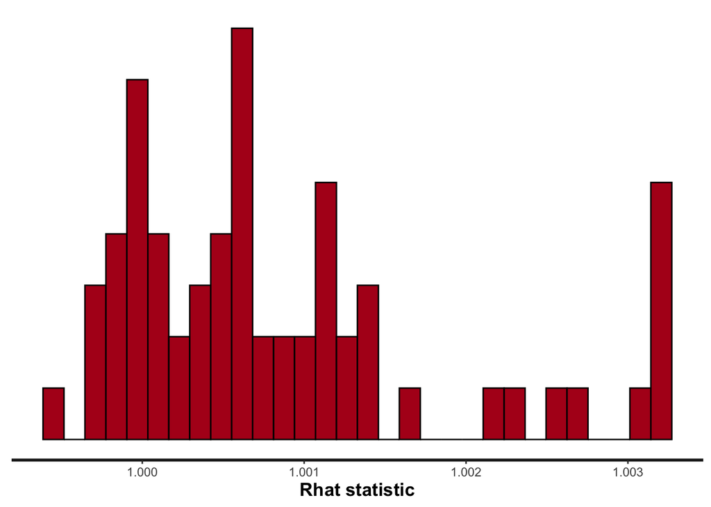

```r
stan_rhat(fit_sir_negbin)
```

### Divergent transition check

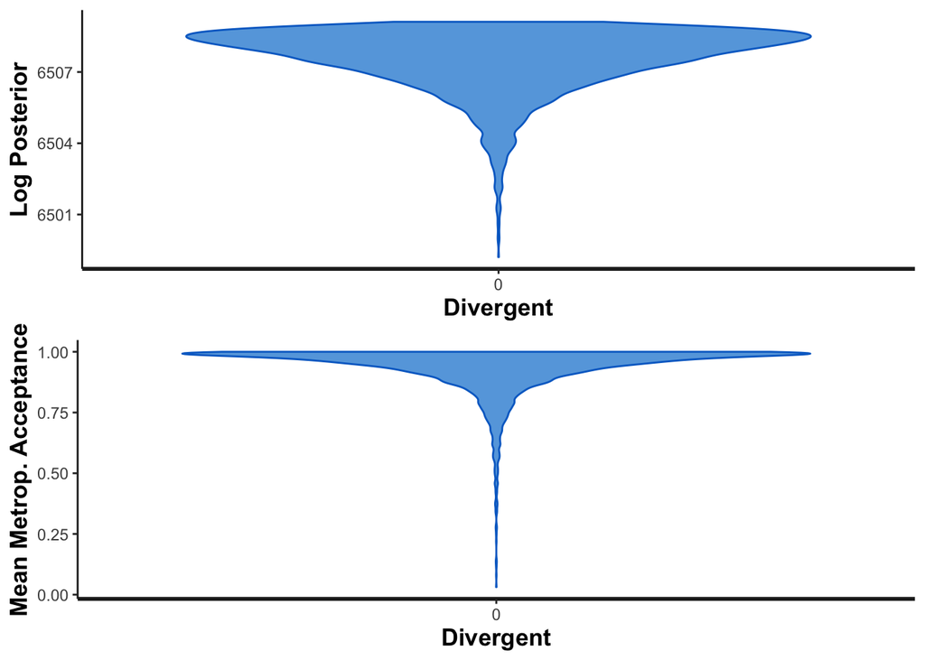

```r
stan_diag(fit_sir_negbin,information="divergence")
```

### Compare marginal posterier densities across chains

These graphs show that posteriors are similar across all 4 chains.

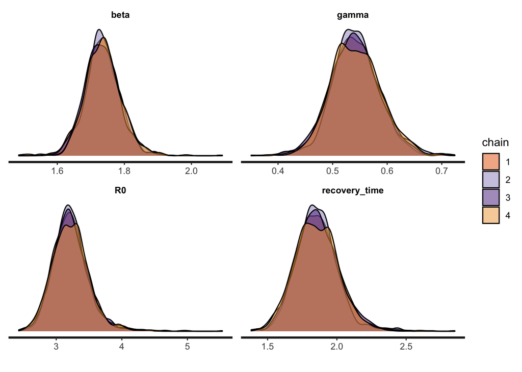

```r
stan_dens(fit_sir_negbin, pars = pars, separate_chains = TRUE)
```

### Posterior predictive check

Predict new data based on estimates–prediction is done in the `generated quantities` block of the Stan program–repeated below.

```
generated quantities {
  real R0 = beta / gamma;
  real recovery_time = 1 / gamma;
  real pred_cases[n_days];
  pred_cases = neg_binomial_2_rng(col(to_matrix(y), 2), phi);
}
```

For each draw of parameter values the `generated quantities` block is executed and the variables `R0`, `recovery_time` and `pred_cases` are computed and stored with the corresponding parameter values. Examining these values can increase our confidence that the model and fit are reasonable.

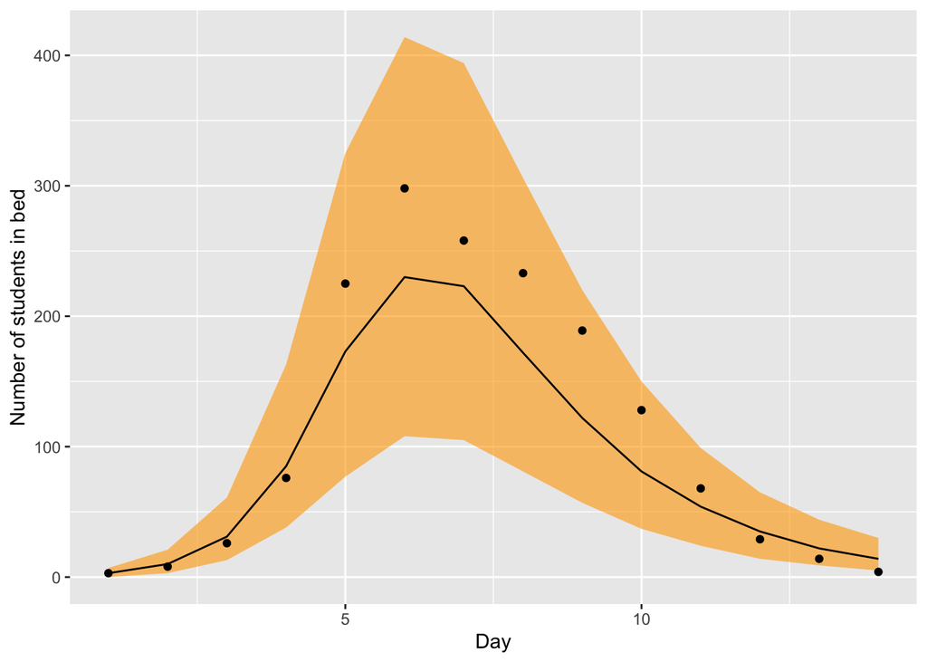

```r
fit.df <- as.data.frame(summary(
  fit_sir_negbin, pars = "pred_cases", probs = c(0.05, 0.5, 0.95))$summary)
smr_pred <- cbind(fit.df, ts, cases)
colnames(smr_pred) <- make.names(colnames(smr_pred)) # to remove % in the col names

ggplot(smr_pred, mapping = aes(x = ts)) +
  geom_ribbon(aes(ymin = X5., ymax = X95.), fill = "orange", alpha = 0.6) +
  geom_line(mapping = aes(x = ts, y = X50.)) +
  geom_point(mapping = aes(y = cases)) +
  labs(x = "Day", y = "Number of students in bed")
```

### Prior predictive check

The prior predictive check estimates the model parameters without data or likelihood being used. The resulting draws are then used to predict new data via predictive application of the likelihood without having seen any data. Note that `compute_likelihood = 0` prevents the likelihood being computed in the model.

```r
compute_likelihood = 0 # will not compute likelihood, allows for prior predictive check
# data for Stan
data_sir <- list(n_days = n_days, y0 = y0, t0 = t0, ts = ts, N = N, cases = cases, compute_likelihood = compute_likelihood)

model <- stan_model("stan/sir_negbin.stan")
fit_sir_negbin_prior_pred_chck <- sampling(model,
                data = data_sir,
                iter = niter,
                chains = 4,
                seed=1590291619) #this seed works, not all will
pars=c('beta', 'gamma', "R0", "recovery_time")
print(fit_sir_negbin_prior_pred_chck, pars = pars)
```

```
Inference for Stan model: sir_negbin.
4 chains, each with iter=2000; warmup=1000; thin=1;
post-warmup draws per chain=1000, total post-warmup draws=4000.

               mean se_mean    sd 2.5%  25%  50%  75% 97.5% n_eff Rhat
beta           2.04    0.02  0.96 0.30 1.36 2.00 2.67  4.01  1575    1
gamma          0.58    0.01  0.38 0.03 0.27 0.53 0.83  1.42  1880    1
R0            13.59     NaN 76.40 0.45 2.07 3.66 7.71 81.39   NaN  NaN
recovery_time  6.89     NaN 48.07 0.71 1.21 1.89 3.68 36.27   NaN  NaN

Samples were drawn using NUTS(diag_e) at Mon Jan 25 11:54:27 2021.
For each parameter, n_eff is a crude measure of effective sample size,
and Rhat is the potential scale reduction factor on split chains (at
convergence, Rhat=1).
```

### Parameter recovery with simulated data

```r
#Pick one arbitrary draw from the prior distribution
draw <- 12

s_prior <- rstan::extract(fit_sir_negbin_prior_pred_chck)
cases_simu <- s_prior$pred_cases[draw,]

compute_likelihood = 1
data_simu <-  list (n_days  = n_days, y0 = y0, t0 = t0, ts = ts, N=N, cases=cases_simu, compute_likelihood = compute_likelihood)
fit_simu <- sampling(model, data=data_simu, chains=4, seed=1316072718)
params = c("beta", "gamma", "phi")
paste("true beta :", toString(s_prior$beta[draw]),
      ", true gamma :", toString(s_prior$gamma[draw]), ", true phi :", toString(s_prior$phi[draw]))
```

```
[1] "true beta : 2.82036654580866 , true gamma : 0.622185745072123 , true phi : 4.4204590224877"
```

Knowing the true generating parameters allows comparison to estimated values shown below:

```r
print(fit_simu, pars = params)
```

```
Inference for Stan model: sir_negbin.
4 chains, each with iter=2000; warmup=1000; thin=1;
post-warmup draws per chain=1000, total post-warmup draws=4000.

      mean se_mean   sd 2.5%  25%  50%  75% 97.5% n_eff Rhat
beta  2.90    0.00 0.18 2.59 2.78 2.88 3.01  3.30  2101    1
gamma 0.60    0.00 0.05 0.52 0.57 0.60 0.63  0.70  1833    1
phi   5.44    0.05 2.47 2.09 3.71 4.95 6.67 11.57  2159    1

Samples were drawn using NUTS(diag_e) at Mon Jan 25 11:56:39 2021.
For each parameter, n_eff is a crude measure of effective sample size,
and Rhat is the potential scale reduction factor on split chains (at
convergence, Rhat=1).
```

All the parameters fit within the 2.5% to to 97.5% interval.

### SBC validation

To be done.